# Practical Machine Learning Project

Agnieszka Chojecka

2026-07-10

# Introduction

The purpose of this project is to predict the manner in which six participants performed a barbell exercise using data collected from wearable accelerometers. The outcome variable is **classe**, which has five possible values (A–E).

# Loading Libraries and Data

First, the required libraries are loaded and the training and testing datasets are imported.

The dimensions of both datasets are checked.

```
## [1] 19622   160
```

```
## [1]  20 160
```

# Data Cleaning

The data were cleaned by:

- removing predictors with near-zero variance,
- removing variables containing missing values,
- removing the first five identification variables.

The dimensions after cleaning are:

```
## [1] 19622    54
```

```
## [1] 20 53
```

# Data Partitioning

The dataset was randomly split into a training set (70%) and a validation set (30%). The validation set was used to estimate the model’s performance on unseen data.

# Model Building

A Random Forest classifier was selected because it performs well for classification problems involving many predictors.

```
##
## Call:
##  randomForest(formula = classe ~ ., data = train, ntree = 100)
##                Type of random forest: classification
##                      Number of trees: 100
## No. of variables tried at each split: 7
##
##         OOB estimate of  error rate: 0.31%
## Confusion matrix:
##      A    B    C    D    E  class.error
## A 3904    2    0    0    0 0.0005120328
## B    5 2652    1    0    0 0.0022573363
## C    0   13 2381    2    0 0.0062604341
## D    0    0   11 2240    1 0.0053285968
## E    0    0    0    7 2518 0.0027722772
```

The figure below presents the importance of the predictors used by the Random Forest model.

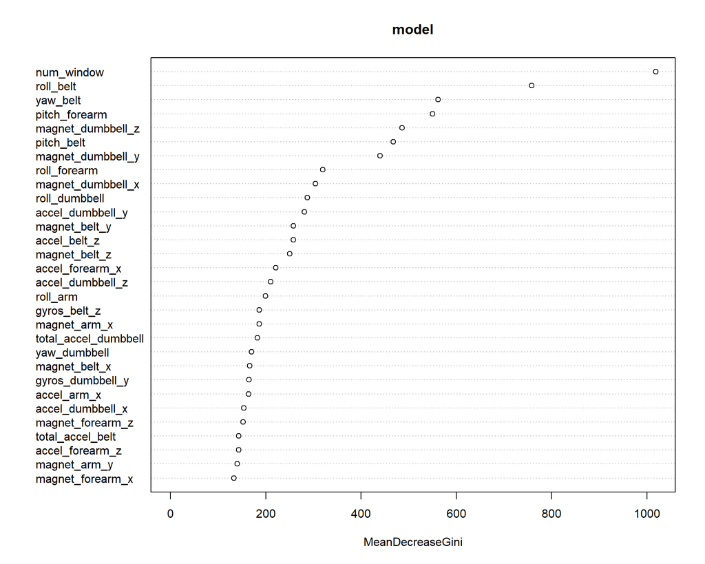

# Model Evaluation

Predictions were made on the validation dataset and evaluated using a confusion matrix.

```
## Confusion Matrix and Statistics
##
##           Reference
## Prediction    A    B    C    D    E
##          A 1674    1    0    0    0
##          B    0 1135    1    0    0
##          C    0    3 1025    4    0
##          D    0    0    0  960    4
##          E    0    0    0    0 1078
##
## Overall Statistics
##
##                Accuracy : 0.9978
##                  95% CI : (0.9962, 0.9988)
##     No Information Rate : 0.2845
##     P-Value [Acc > NIR] : < 2.2e-16
##
##                   Kappa : 0.9972
##
##  Mcnemar's Test P-Value : NA
##
## Statistics by Class:
##
##                      Class: A Class: B Class: C Class: D Class: E
## Sensitivity            1.0000   0.9965   0.9990   0.9959   0.9963
## Specificity            0.9998   0.9998   0.9986   0.9992   1.0000
## Pos Pred Value         0.9994   0.9991   0.9932   0.9959   1.0000
## Neg Pred Value         1.0000   0.9992   0.9998   0.9992   0.9992
## Prevalence             0.2845   0.1935   0.1743   0.1638   0.1839
## Detection Rate         0.2845   0.1929   0.1742   0.1631   0.1832
## Detection Prevalence   0.2846   0.1930   0.1754   0.1638   0.1832
## Balanced Accuracy      0.9999   0.9981   0.9988   0.9975   0.9982
```

The estimated accuracy of the model is:

```
## Accuracy
## 0.997791
```

The estimated out-of-sample error is:

```
##    Accuracy
## 0.002209006
```

The Random Forest model achieved a very high accuracy, indicating that it is appropriate for predicting the exercise classes.

# Prediction on Test Data

Finally, predictions were generated for the 20 observations in the testing dataset.

```
##  1  2  3  4  5  6  7  8  9 10 11 12 13 14 15 16 17 18 19 20
##  B  A  B  A  A  E  D  B  A  A  B  C  B  A  E  E  A  B  B  B
## Levels: A B C D E
```

# Conclusion

After cleaning the data and training a Random Forest model, the classifier achieved a high prediction accuracy on the validation dataset. The trained model was then used to predict the exercise classes for the 20 observations in the testing dataset.